# BUA 345 Lecture 18 - Quiz 2 Review

Penelope Pooler Eisenbies

2023-03-28

### Upcoming Dates

- **HW 8 was due on Monday, 3/27**.
  - Grace Period ends tonight (Tues. 3/28) at midnight.
- **Quiz 2 is Thursday, March 30th**
  - Practice Questions were posted on Saturday (3/25)

### Getting Started with Markdown (Updated)

- Download Zipped R project
- Open Zipped folder and copy internal folder (R Project) to a BUA 345 folder on your computer NOT IN DOWLOADS
- **Open R Project:**
  - *OPTION 1:* Click on .Rproj file to open project and RStudio
  - *OPTION 2:* Open RStudio, then click File > Open Project > then navigate to and click on .Rproj file.
- **Once Project is opened in RStudio:**
  - Click on `code_data_output` file to open it.
  - Click on `BUA_345_Lecture_18.Rmd` to open it.
  - Run `setup` Chunk

### Setup Chunk for Lecture 18

```r
# this line specifies options for default options for all R Chunks
knitr::opts_chunk$set(echo=T, highlight=T)
# suppress scientific notation
options(scipen=100)

# install helper package that loads and installs other packages, if needed
if (!require("pacman")) install.packages("pacman", repos = "http://lib.stat.cmu.edu/R/CRAN/")
# install and load required packages
pacman::p_load(pacman,tidyverse, magrittr, olsrr, gridExtra, ggiraphExtra, knitr, viridis, blorr)

# verify packages
p_loaded()
```

```
##  [1] "blorr"        "viridis"      "viridisLite"  "knitr"        "ggiraphExtra"
##  [6] "gridExtra"    "olsrr"        "magrittr"     "forcats"      "stringr"
## [11] "dplyr"        "purrr"        "readr"        "tidyr"        "tibble"
## [16] "ggplot2"      "tidyverse"    "pacman"
```

**NOTES:**

- Please make sure you can open the provided R project for the practice questions and run the setup chunk without errors.
- If you are having trouble installing/loading any packages, please come to office hour or make an appointment with me or course TA.

### Lectures 9 - 11 (HW 5)

**Correlation, SLR, and MLR**

- Simple Linear Regression and Multiple Linear Regression
- How to calculate and interpret a correlation matrix in R
- Revive of Scatterplot Matrices

```r
# imported dataset is saved as an object named houses
houses <- read_csv("houses.csv", show_col_types=F) |> glimpse()
```

```
## Rows: 200
## Columns: 4
## $ Price     <dbl> 217314, 238792, 222330, 206688, 88207, 236936, 90678, 104556…
## $ Area      <dbl> 2498, 2250, 2712, 2284, 1480, 2300, 957, 1673, 3003, 957, 14…
## $ Bathrooms <dbl> 2.5, 2.5, 3.0, 2.5, 1.5, 2.5, 1.0, 2.0, 3.5, 1.0, 1.5, 1.0, …
## $ Age       <dbl> 14, 10, 1, 17, 14, 16, 49, 18, 88, 49, 3, 180, 14, 33, 19, 3…
```

### Lecture 17 In-class Exercises - Session ID: bua345s23**

#### **Question 2 (L18)

Are there any multicollinear variables in the following dataset?

```r
houses |> cor() |> round(2) # correlation matrix
```

```
##           Price  Area Bathrooms   Age
## Price      1.00  0.77      0.71 -0.38
## Area       0.77  1.00      0.66 -0.22
## Bathrooms  0.71  0.66      1.00 -0.52
## Age       -0.38 -0.22     -0.52  1.00
```

### Correlation Matrices and Scatterplot matrices

```
##           Price  Area Bathrooms   Age
## Price      1.00  0.77      0.71 -0.38
## Area       0.77  1.00      0.66 -0.22
## Bathrooms  0.71  0.66      1.00 -0.52
## Age       -0.38 -0.22     -0.52  1.00
```

#### Scatterplot matrices graphically display the information in the correlation matrix.

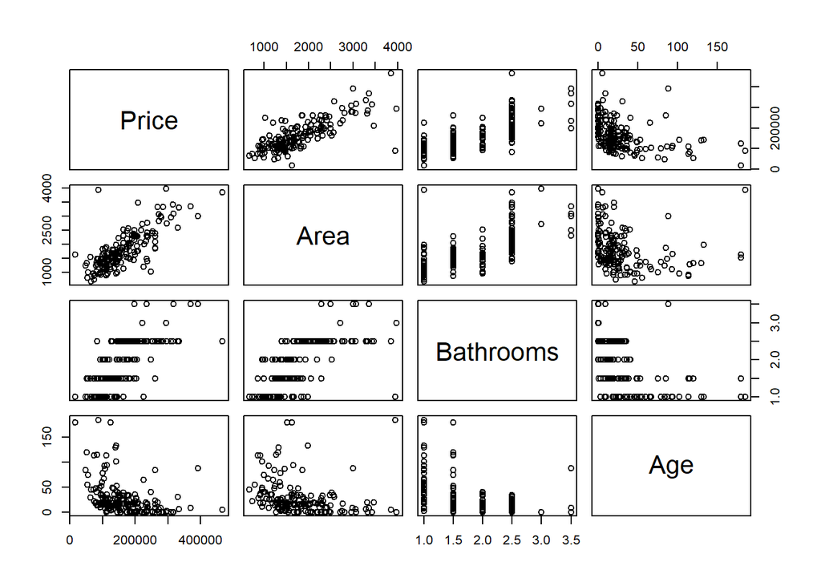